# Проект. Исследование стартапов

Автор: **Егоров Д.Д.**  
Дата: **24.01.2026**

## Введение

**Знакомство с проектом:**  
Финансовая компания, работающая с венчурными инвестициями, хочет понять закономерности финансирования стартапов и оценить перспективы выхода на рынок с покупкой и развитием компаний. Для этого необходимо провести исследование на исторических данных. Необходимо проанализировать информацию о компаниях, объёмах и типах привлечённых инвестиций, а также дополнительную статистику по возвратам средств.

**Задача проекта:**  
Подготовить датасет к работе, исследовать динамику и структуру финансирования стартапов и ответить на вопросы, важные для оценки инвестиционных стратегий.

**В рамках проекта предстоит выполнить следующие шаги:**

- Провести предобработку данных, убрать дубликаты и пропуски, проверить корректность числовых и временных значений.
- Выделить группы компаний по срокам финансирования и сравнить их по количеству и объёму инвестиций.
- Классифицировать сегменты рынка на массовые, средние и нишевые и учесть это в дальнейшем анализе.
- Определить типичные и аномальные значения объёмов финансирования, исключить выбросы и ограничить период исследования.
- Сравнить популярность и объёмы разных типов финансирования.
- Проанализировать динамику раундов и объёмов инвестиций по годам, а также изменения в массовых сегментах рынка.
- Рассчитать долю возврата средств для разных типов финансирования и оценить её устойчивость.
- Подвести итоговые выводы и дать рекомендации, куда и каким образом было бы целесообразно инвестировать, если бы на дворе был 2015 год.

## Шаг 1. Знакомство с данными: загрузка и предобработка

Датасет получен из базы данных стартапов.

Название основного датасета — `cb_investments.zip`. Внутри архива один файл — `cb_investments.csv`. Он содержит информацию о компаниях и состоявшемся финансировании.

Описание данных `cb_investments.csv`:

- `name` — название компании.
- `homepage_url` — ссылка на сайт компании.
- `category_list` — категории, в которых работает компания. Указываются через `|`.
- `market` — основной рынок или отрасль компании.
- `funding_total_usd` — общий объём привлечённых инвестиций в долларах США.
- `status` — текущий статус компании, например `operating`, `closed` и так далее.
- `country_code` — код страны, например USA.
- `state_code` — код штата или региона, например, CA.
- `region` — регион, например, SF Bay Area.
- `city` — город, в котором расположена компания.
- `funding_rounds` — общее число раундов финансирования.
- `participants` — число участников в раундах финансирования.
- `founded_at` — дата основания компании.
- `founded_month` — месяц основания в формате `YYYY-MM`.
- `founded_quarter` — квартал основания в формате `YYYY-QN`.
- `founded_year` — год основания.
- `first_funding_at` — дата первого финансирования.
- `mid_funding_at` — дата среднего по времени раунда финансирования.
- `last_funding_at` — дата последнего финансирования.
- `seed` — сумма инвестиций на посевной стадии.
- `venture` — сумма венчурных инвестиций.
- `equity_crowdfunding` — сумма, привлечённая через долевой краудфандинг.
- `undisclosed` — сумма финансирования нераскрытого типа.
- `convertible_note` — сумма инвестиций через конвертируемые займы.
- `debt_financing` — сумма долгового финансирования.
- `angel` — сумма инвестиций от бизнес-ангелов.
- `grant` — сумма полученных грантов.
- `private_equity` — сумма инвестиций в виде прямых (частных) вложений.
- `post_ipo_equity` — сумма финансирования после IPO.
- `post_ipo_debt` — сумма долгового финансирования после IPO.
- `secondary_market` — сумма сделок на вторичном рынке.
- `product_crowdfunding` — сумма, привлечённая через продуктовый краудфандинг.
- `round_A` — `round_H` — сумма инвестиций в соответствующем раунде.

Название дополнительного датасета — `cb_returns.csv`. Он содержит суммы возвратов по типам финансирования в миллионах долларов по годам.

Описание данных `cb_returns.csv`:

- `year` — год возврата средств.
- `seed` — сумма возвратов от посевных инвестиций.
- `venture` — сумма возвратов от венчурных инвестиций.
- `equity_crowdfunding` — сумма, возвращённая по долевому краудфандингу.
- `undisclosed` — сумма возвратов нераскрытого типа.
- `convertible_note` — сумма возвратов через конвертируемые займы.
- `debt_financing` — сумма возвратов от долгового финансирования.
- `angel` — сумма возвратов бизнес-ангелам.
- `grant` — сумма возвратов по грантам.
- `private_equity` — сумма возвратов прямых (частных) вложений.
- `post_ipo_equity` — сумма возвратов от IPO.
- `post_ipo_debt` — сумма возвратов от долгового IPO.
- `secondary_market` — сумма возвратов от сделок на вторичном рынке.
- `product_crowdfunding` — сумма возвратов по продуктовому краудфандингу.

Файлы находятся в папке `datasets`, если вы выполняете работу на платформе. В случае, если вы делаете работу локально, доступ к файлам в папке можно получить по адресу `https://code.s3.yandex.net/datasets/` + имя файла.

### 1.1. Вывод общей информации

Начнём с загрузки библиотек и датасетов **cb_investments.csv** (взятый из cb_investments.zip) и **cb_returns.csv**. Будем использовать **pandas** и дополнительные библиотеки визуализации данных, такие как **matplotlib (pyplot и ticker)**, **seaborn**, **phik** а также **missingno**. Данные датасетов сохраним в двух переменных: `inv_df` и `rtn_df`.

```python
# Импортируем все необходимые библиотеки
try:
    import pandas as pd
    import matplotlib.pyplot as plt
    import matplotlib.ticker as ticker
    import seaborn as sns
    import phik
    import missingno as msn
except ImportError:
    !pip install pandas matplotlib seaborn phik missingno
    import pandas as pd
    import matplotlib.pyplot as plt
    import matplotlib.ticker as ticker
    import seaborn as sns
    import phik
    import missingno as msno
```

```python
# Выгружаем данные в переменные inv_df и ret_df
inv_df = pd.read_csv("https://code.s3.yandex.net/datasets/cb_investments.zip", sep=';', low_memory=False)
rtn_df = pd.read_csv('https://code.s3.yandex.net/datasets/cb_returns.csv')
```

Познакомимся с данными обоих датасетов — выведем общую информацию и первые строки созданных датафреймов методами info() и head(), а также посчитаем пропуски и визуализируем их через библиотеку missingno.

#### ==== ДАННЫЕ О ДАТАФРЕЙМЕ INVESTMENTS ====

```python
# Выводим общую информацию и первые 10 строк датафрейма investments
inv_df.info()
inv_df.head(10)
```

```
<class 'pandas.core.frame.DataFrame'>
RangeIndex: 54294 entries, 0 to 54293
Data columns (total 40 columns):
 #   Column                Non-Null Count  Dtype
---  ------                --------------  -----
 0   name                  49437 non-null  object
 1   homepage_url          45989 non-null  object
 2   category_list         45477 non-null  object
 3    market               45477 non-null  object
 4    funding_total_usd    49438 non-null  object
 5   status                48124 non-null  object
 6   country_code          44165 non-null  object
 7   state_code            30161 non-null  object
 8   region                44165 non-null  object
 9   city                  43322 non-null  object
```

[output cut: 32 more lines]

|  | name | homepage_url | category_list | market | funding_total_usd | status | country_code | state_code | region | city | ... | secondary_market | product_crowdfunding | round_A | round_B | round_C | round_D | round_E | round_F | round_G | round_H |
| --- | --- | --- | --- | --- | --- | --- | --- | --- | --- | --- | --- | --- | --- | --- | --- | --- | --- | --- | --- | --- | --- |
| 0 | Harvard University | http://harvard.edu | \|Education\| | Education | 9,00,00,000 | operating | USA | MA | Boston | Cambridge | ... | 0.0 | 0.0 | 0.0 | 0.0 | 0.0 | 0.0 | 0.0 | 0.0 | 0.0 | 0.0 |
| 1 | University of New Brunswick | http://www.unb.ca | NaN | NaN | 20,00,000 | operating | NaN | NaN | NaN | NaN | ... | 0.0 | 0.0 | 0.0 | 0.0 | 0.0 | 0.0 | 0.0 | 0.0 | 0.0 | 0.0 |
| 2 | DuPont | http://www.dupont.com | \|Business Services\|Agriculture\|Automotive\|Inve... | Business Services | 90,00,000 | operating | USA | DE | Wilmington, Delaware | Wilmington | ... | 0.0 | 0.0 | 0.0 | 0.0 | 0.0 | 0.0 | 0.0 | 0.0 | 0.0 | 0.0 |
| 3 | University of Michigan | http://www.umich.edu/ | \|Education\| | Education | 77,00,000 | operating | USA | MI | Detroit | Ann Arbor | ... | 0.0 | 0.0 | 0.0 | 0.0 | 0.0 | 0.0 | 0.0 | 0.0 | 0.0 | 0.0 |
| 4 | Case Western Reserve University | http://www.case.edu | \|Education\| | Education | 5,40,000 | operating | USA | OH | Cleveland | Cleveland | ... | 0.0 | 0.0 | 0.0 | 0.0 | 0.0 | 0.0 | 0.0 | 0.0 | 0.0 | 0.0 |
| 5 | Xavier University | http://www.xavier.edu/ | NaN | NaN | 1,90,00,000 | operating | USA | OH | Cincinnati | Cincinnati | ... | 0.0 | 0.0 | 0.0 | 0.0 | 0.0 | 0.0 | 0.0 | 0.0 | 0.0 | 0.0 |
| 6 | Tulane University | http://tulane.edu/ | \|Education\| | Education | 1,20,00,000 | operating | USA | LA | New Orleans | New Orleans | ... | 0.0 | 0.0 | 0.0 | 0.0 | 0.0 | 0.0 | 0.0 | 0.0 | 0.0 | 0.0 |
| 7 | Duke University | http://www.duke.edu | \|Education\| | Education | 87,00,000 | operating | USA | NC | Raleigh | Durham | ... | 0.0 | 0.0 | 0.0 | 0.0 | 0.0 | 0.0 | 0.0 | 0.0 | 0.0 | 0.0 |
| 8 | Virginia Commonwealth University, Richmond | http://www.vcu.edu/ | NaN | NaN | 60,00,000 | operating | USA | VA | Richmond | Richmond | ... | 0.0 | 0.0 | 0.0 | 0.0 | 0.0 | 0.0 | 0.0 | 0.0 | 0.0 | 0.0 |
| 9 | WeGame | http://www.WeGame.com | \|Social Media\| | Social Media | 35,00,000 | acquired | USA | CA | SF Bay Area | San Francisco | ... | 0.0 | 0.0 | 3000000.0 | 0.0 | 0.0 | 0.0 | 0.0 | 0.0 | 0.0 | 0.0 |

10 rows × 40 columns

```
Доля пропущенных значений по столбцам:
name                     8.95%
homepage_url             15.3%
category_list           16.24%
 market                 16.24%
 funding_total_usd       8.94%
status                  11.36%
country_code            18.66%
state_code              44.45%
region                  18.66%
city                    20.21%
funding_rounds           8.94%
participants            43.87%
founded_at              28.99%
founded_month           29.12%
founded_quarter         29.12%
founded_year            28.99%
first_funding_at         8.94%
mid_funding_at          44.21%
last_funding_at          8.94%
seed                     8.94%
venture                  8.94%
equity_crowdfunding      8.94%
undisclosed              8.94%
convertible_note         8.94%
debt_financing           8.94%
angel                    8.94%
grant                    8.94%
private_equity           8.94%
post_ipo_equity          8.94%
post_ipo_debt            8.94%
secondary_market         8.94%
product_crowdfunding     8.94%
round_A                  8.94%
round_B                  8.94%
round_C                  8.94%
round_D                  8.94%
round_E                  8.94%
round_F                  8.94%
round_G                  8.94%
round_H                  8.94%
dtype: object
```

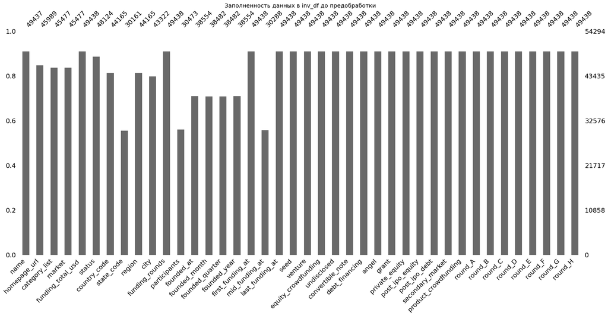

```python
# Считаем и выводим долю пропущенных значений в каждом столбце датафрейма investments
print(f'Доля пропущенных значений по столбцам:\n{(inv_df.isna().sum() / inv_df.shape[0] * 100).round(2).astype(str) + '%'}')

# Визуализируем состояние датафрейма investments через библиотеку missingno
msn.bar(inv_df)
plt.title('Заполненность данных в inv_df до предобработки', fontsize=14)
plt.show()
```

Датасет `cb_investments.csv` содержит **40 столбцов** и **54294 строк**, в которых представлена информация о компаниях и состоявшемся финансировании.

После первичного анализа данных можно сделать следующие выводы:

- Названия столбцов уже приведены к удобному для работы формату snake_case, поэтому менять их не требуется.
- В выводе .info() заметно, что перед названиями столбцов `market` и `funding_total_usd` стоят пробелы. Их необходимо будет обработать, иначе это будет вызывать ошибки при обращении к этим столбцам по имени.
- В столбце `category_list` значения указаны через символ "|". Это может вызвать ошибки при обработке данных, поэтому содержимое данного столбца, скорее всего, придётся переделать в более удобный вид.
- Данные датасета представлена двумя типами - **object** и **float64**. Для большей части столбцов используется правильный тип данных. Неправильный тип данных выбран для следующего списка столбцов:
  - `funding_total_usd` — необходимо перевести из **object** во **float64**
  - `participants` — необходимо перевести из **float64** в **Int64**
  - `funding_rounds` — необходимо перевести из **float64** в **Int64**
  - `founded_at` — необходимо перевести из **object** в **datetime64**
  - `founded_month` и `founded_quarter` — необходимо вычленить из `founded_at` (содержащим полную дату) и сохранить в **datetime64**
  - `founded_year` — необходимо перевести из **float64** в **datetime64**
  - `first_funding_at` — необходимо перевести из **object** в **datetime64**
  - `mid_funding_at` — необходимо перевести из **object** в **datetime64**
  - `last_funding_at` — необходимо перевести из **object** в **datetime64**

Касательно пропусков:

- Пропуски в данных имеют неоднородный характер. Так, 2/3 датафрейма состоит из столбцов, в которых пропущено ровно 8.94–8.95% данных. Это очевидно не является совпадением и указывает на то, что в датасете около 4856 полностью пустых (или практически пустых) строк. Причина появления этих пропусков скорее всего техническая (например ошибка при выгрузке или объединении таблиц). Данные строки желательно удалить на этапе предобработки данных.
- Пропуски в столбцах `founded_at`, `founded_month`, `founded_quarter` и `founded_year` (доля пропусков от 28.99% до 29.12%) могут быть связаны с отсутсвием исторической справки для ряда компаний.
- Пропуски в столбцах `city` (20.21%), а также `region` и `country_code` (18.66%) могли появится как из-за технической ошибки, так и из-за намернного сокрытия этой информации первоначальным источником.
- Пропуски в столбце `state_code` (44.45%) скорее всего появились из-за географической специфики. Маркер штата обычно является обязательным и понятным для компаний из США или Австралии, но для европейских, азиатских или российских компаний это поле часто игнорируется при заполнении или вовсе не предусмотрено в интерфейсе сбора данных.
- Пропуски в столбце `participants` (43.87%) могут быть связаны с тем, что бизнес-сделки часто являются непубличными.
- Пропуски в `mid_funding_at` (44.21%) предположительно связаны с тем, что дата среднего по времени раунда финансирования вычисляется только если у компании было 3 и более таких раундов. Если у компании был менее 3 раундов, «середина» либо совпадает с краями, либо не имеет смысла. Пропуски здесь — признак молодых компаний или тех, кто закрылся после первых инвестиций.

#### ==== ДАННЫЕ О ДАТАФРЕЙМЕ RETURNS ====

```python
# Выводим общую информацию и первые 10 строк датафрейма returns
rtn_df.info()
rtn_df.head(10)
```

```
<class 'pandas.core.frame.DataFrame'>
RangeIndex: 15 entries, 0 to 14
Data columns (total 14 columns):
 #   Column                Non-Null Count  Dtype
---  ------                --------------  -----
 0   year                  15 non-null     int64
 1   seed                  15 non-null     float64
 2   venture               15 non-null     float64
 3   equity_crowdfunding   15 non-null     float64
 4   undisclosed           15 non-null     float64
 5   convertible_note      15 non-null     float64
 6   debt_financing        15 non-null     float64
 7   angel                 15 non-null     float64
 8   grant                 15 non-null     float64
 9   private_equity        15 non-null     float64
 10  post_ipo_equity       15 non-null     float64
 11  post_ipo_debt         15 non-null     float64
 12  secondary_market      15 non-null     float64
 13  product_crowdfunding  15 non-null     float64
dtypes: float64(13), int64(1)
memory usage: 1.8 KB
```

|  | year | seed | venture | equity_crowdfunding | undisclosed | convertible_note | debt_financing | angel | grant | private_equity | post_ipo_equity | post_ipo_debt | secondary_market | product_crowdfunding |
| --- | --- | --- | --- | --- | --- | --- | --- | --- | --- | --- | --- | --- | --- | --- |
| 0 | 2000 | 16.70 | 55.40 | 0.00 | 78.21 | 0.00 | 8.66 | 6.43 | 0.0 | 0.00 | 0.94 | 0.0 | 0.20 | 0.00 |
| 1 | 2001 | 2.88 | 23.49 | 0.00 | 21.50 | 0.01 | 4.49 | 1.18 | 0.0 | 0.00 | 0.46 | 0.0 | 0.46 | 0.00 |
| 2 | 2002 | 6.59 | 209.42 | 0.00 | 25.77 | 0.02 | 3.42 | 3.41 | 0.0 | 1.51 | 0.34 | 0.0 | 0.06 | 0.00 |
| 3 | 2003 | 7.74 | 233.86 | 0.00 | 9.40 | 0.01 | 1.09 | 3.41 | 0.0 | 1.62 | 2.11 | 0.0 | 0.08 | 0.00 |
| 4 | 2004 | 9.93 | 555.90 | 0.00 | 33.19 | 0.01 | 13.55 | 9.18 | 0.0 | 2.19 | 3.38 | 0.0 | 0.55 | 0.00 |
| 5 | 2005 | 26.60 | 2628.92 | 0.00 | 9.51 | 0.02 | 35.09 | 31.06 | 0.0 | 2.40 | 3.51 | 0.0 | 0.05 | 0.00 |
| 6 | 2006 | 61.81 | 3100.18 | 0.19 | 46.74 | 1.78 | 113.21 | 47.75 | 0.0 | 16.67 | 20.58 | 0.0 | 0.12 | 0.00 |
| 7 | 2007 | 70.41 | 3585.37 | 0.01 | 55.37 | 3.22 | 125.68 | 164.51 | 0.0 | 88.81 | 24.36 | 0.0 | 0.57 | 0.00 |
| 8 | 2008 | 89.72 | 2717.02 | 0.03 | 41.02 | 1.71 | 397.54 | 102.83 | 0.0 | 130.38 | 84.28 | 0.0 | 0.47 | 0.00 |
| 9 | 2009 | 160.21 | 2501.29 | 0.18 | 37.50 | 2.25 | 394.10 | 97.21 | 0.0 | 203.70 | 76.76 | 0.0 | 0.12 | 0.02 |

```
Доля пропущенных значений по столбцам:
year                    0.0%
seed                    0.0%
venture                 0.0%
equity_crowdfunding     0.0%
undisclosed             0.0%
convertible_note        0.0%
debt_financing          0.0%
angel                   0.0%
grant                   0.0%
private_equity          0.0%
post_ipo_equity         0.0%
post_ipo_debt           0.0%
secondary_market        0.0%
product_crowdfunding    0.0%
dtype: object
```

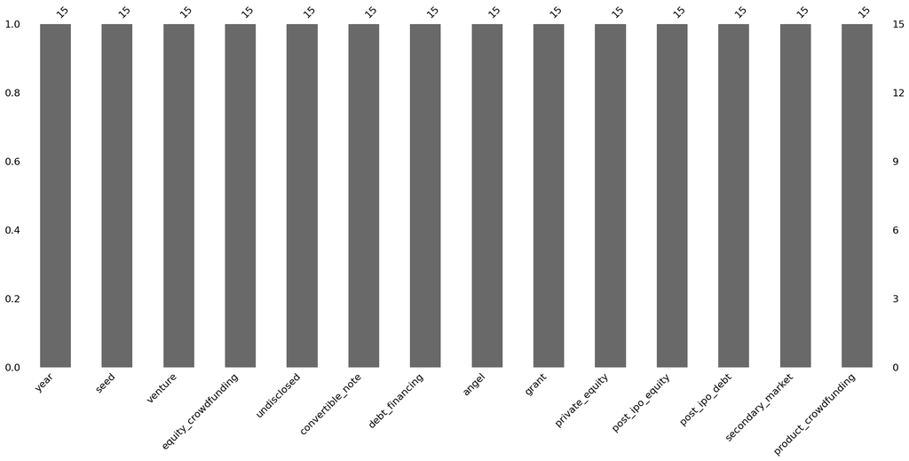

```python
# Считаем и выводим долю пропущенных значений в каждом столбце датафрейма returns
print(f'Доля пропущенных значений по столбцам:\n{(rtn_df.isna().sum() / rtn_df.shape[0] * 100).round(2).astype(str) + '%'}')

# Визуализируем состояние датафрейма returns через библиотеку missingno
msn.bar(rtn_df)
plt.show()
```

Датасет `cb_returns.csv` содержит **14 столбцов** и **15 строк**, в которых представлена информация об объёмах возвратов по годам и типам финансирования в миллионах долларов.

После первичного анализа данных можно сделать следующие выводы:

- Названия столбцов уже приведены к удобному для работы формату snake_case, поэтому менять их не требуется.
- Типы данных подобраны верно. Столбец `year` имеет тип **int64** (что логично для года), а все остальные столбцы с финансовыми показателями — **float64** (что необходимо для денежных сумм).
- В данных полностью отсутствуют пропуски.
- Финансовые показатели указаны в сокращённом формате (в миллионах долларов) — на это стоит обратить внимание при сравнении данных между двумя датасетами, так как в `cb_investments.csv` суммы были указаны полностью. Для удобства, рекомендуется привести финансовые показатели из датасета `cb_returns.csv` в аналогичный формат, умножив все значения на 1000000.

### Промежуточные выводы

Перед дальнейшим анализом данных, необходимо учесть следующие моменты:

- Два выделенных датафрейма не следует объединять в один. Во-первых, потому что они имеют разный уровень детализации. `inv_df` — это микроданные, где каждая строка — это отдельная компания. `rtn_df` — это макроданные, где каждая строка — это итог по всему рынку за целый год. Если попытаться объединить их по году, то это продублирует рыночные показатели для каждой компании этого года, что не даст новой информации о самой компании, но раздует таблицу. Во-вторых, у них отсутствует общий ключ. В датафрейме `rtn_df` нет названий компаний или ID, а значит мы не можем узнать, сколько вернула конкретная фирма. Частичная связь возможна только по столбцу `year`, но даты в двух таблицах не соотносятся напрямую и такое объединение приведёт только к большей путанице. Вместо объединения в одну таблицу, датафреймы следует использовать для сопоставительного анализа, как два независимых источника.
- Датафрейм `inv_df` нуждается в обязательной предобработке данных:
  - преобразование имён столбцов, содержащих лишние пробелы;
  - удаление пустых строк;
  - изменение типов данных ряда столбцов.

### 1.2. Предобработка данных

Приступим к предобработке данных. Начнём с датафрейма inv_df.

```python
# Очистка названий столбцов от лишних пробелов
inv_df.columns = inv_df.columns.str.strip()

# Удаление строк где отсутствует название компании (так как они не пригодны для анализа)
inv_df = inv_df.dropna(subset=['name']).copy()

# Удаление полных дубликатов
inv_df = inv_df.drop_duplicates()

# Обработка текстовых пропусков
# (заполняем пропуски в ключевых текстовых полях заглушкой 'unknown')
text_columns_fix = ['homepage_url', 'market', 'country_code', 'state_code', 'region', 'city', 'status']
for col in text_columns_fix:
    inv_df[col] = inv_df[col].replace('-', 'unknown').fillna('unknown')

# Обработка столбца category_list
# (избавляемся от пустых значений и дефисов а также создаём в ячейках данного столбца списки для упрощения анализа)
inv_df['category_list'] = inv_df['category_list'].replace('-', 'Other')
inv_df['category_list'] = inv_df['category_list'].fillna('Other').str.split('|')

# Обработка столбца market
# (избавляемся от лишних пробелов)
inv_df['market'] = inv_df['market'].str.strip()

# Обработка столбца funding_total_usd
# (убираем лишние символы и удаляем пустые строки)
inv_df['funding_total_usd'] = pd.to_numeric(
    inv_df['funding_total_usd'].astype(str).str.replace(r'[^\d.]', '', regex=True),
    errors='coerce'
)
inv_df = inv_df.dropna(subset=['funding_total_usd'])

# Обработка столбцов participants и funding_rounds
for col in ['participants', 'funding_rounds']:
    inv_df[col] = pd.to_numeric(inv_df[col], errors='coerce').astype('Int64')
```

```python
# Обработка столбцов с датами
date_cols = ['founded_at', 'first_funding_at', 'mid_funding_at', 'last_funding_at']

for col in date_cols:
    # Принудительно приводим всё к строке и убираем лишние пробелы по краям
    # Конвертируем в дату
    # Всё, что не похоже на дату автоматически превратится в NaT (пустоту для дат) благодаря errors='coerce'
    inv_df[col] = pd.to_datetime(inv_df[col].astype(str).str.strip(), errors='coerce', format='mixed')

# Удаляем строки, где нет даты первого или последнего финансирования
inv_df = inv_df.dropna(subset=['first_funding_at', 'last_funding_at'])

# Заполнение пропусков в столбце mid_funding_at на основании первой и последней даты
# (создаем фильтр (mask), который отбирает только те компании, которые подходят под три условия одновременно:
# mid_funding_at.isna() — средняя дата пустая;
# first_funding_at.notna() — есть первая дата;
# last_funding_at.notna() — есть последняя дата;)
mask = (inv_df['mid_funding_at'].isna()) & \
       (inv_df['first_funding_at'].notna()) & \
       (inv_df['last_funding_at'].notna())

# Вычисление середины интервала
inv_df.loc[mask, 'mid_funding_at'] = inv_df.loc[mask, 'first_funding_at'] + \
                                     (inv_df.loc[mask, 'last_funding_at'] - inv_df.loc[mask, 'first_funding_at']) / 2

# Формирование производных даты
inv_df['founded_month'] = inv_df['founded_at'].dt.to_period('M').dt.to_timestamp()
inv_df['founded_quarter'] = inv_df['founded_at'].dt.to_period('Q').dt.to_timestamp()
inv_df['founded_year'] = inv_df['founded_at'].dt.to_period('Y').dt.to_timestamp()
```

```python
# Подсчёт оставшихся пропусков в столбце mid_funding_at
print(f"Итоговое количество пропусков в столбце mid_funding_at: {inv_df['mid_funding_at'].isna().sum()}")

print("Обновлённая информация о датафрейме inv_df:")
inv_df.info()
inv_df.head(10)
```

```
Итоговое количество пропусков в столбце mid_funding_at: 0
Обновлённая информация о датафрейме inv_df:
<class 'pandas.core.frame.DataFrame'>
Index: 40904 entries, 0 to 49437
Data columns (total 40 columns):
 #   Column                Non-Null Count  Dtype
---  ------                --------------  -----
 0   name                  40904 non-null  object
 1   homepage_url          40904 non-null  object
 2   category_list         40904 non-null  object
 3   market                40904 non-null  object
 4   funding_total_usd     40904 non-null  float64
 5   status                40904 non-null  object
 6   country_code          40904 non-null  object
 7   state_code            40904 non-null  object
```

[output cut: 34 more lines]

|  | name | homepage_url | category_list | market | funding_total_usd | status | country_code | state_code | region | city | ... | secondary_market | product_crowdfunding | round_A | round_B | round_C | round_D | round_E | round_F | round_G | round_H |
| --- | --- | --- | --- | --- | --- | --- | --- | --- | --- | --- | --- | --- | --- | --- | --- | --- | --- | --- | --- | --- | --- |
| 0 | Harvard University | http://harvard.edu | [, Education, ] | Education | 90000000.0 | operating | USA | MA | Boston | Cambridge | ... | 0.0 | 0.0 | 0.0 | 0.0 | 0.0 | 0.0 | 0.0 | 0.0 | 0.0 | 0.0 |
| 1 | University of New Brunswick | http://www.unb.ca | [Other] | unknown | 2000000.0 | operating | unknown | unknown | unknown | unknown | ... | 0.0 | 0.0 | 0.0 | 0.0 | 0.0 | 0.0 | 0.0 | 0.0 | 0.0 | 0.0 |
| 2 | DuPont | http://www.dupont.com | [, Business Services, Agriculture, Automotive,... | Business Services | 9000000.0 | operating | USA | DE | Wilmington, Delaware | Wilmington | ... | 0.0 | 0.0 | 0.0 | 0.0 | 0.0 | 0.0 | 0.0 | 0.0 | 0.0 | 0.0 |
| 3 | University of Michigan | http://www.umich.edu/ | [, Education, ] | Education | 7700000.0 | operating | USA | MI | Detroit | Ann Arbor | ... | 0.0 | 0.0 | 0.0 | 0.0 | 0.0 | 0.0 | 0.0 | 0.0 | 0.0 | 0.0 |
| 4 | Case Western Reserve University | http://www.case.edu | [, Education, ] | Education | 540000.0 | operating | USA | OH | Cleveland | Cleveland | ... | 0.0 | 0.0 | 0.0 | 0.0 | 0.0 | 0.0 | 0.0 | 0.0 | 0.0 | 0.0 |
| 5 | Xavier University | http://www.xavier.edu/ | [Other] | unknown | 19000000.0 | operating | USA | OH | Cincinnati | Cincinnati | ... | 0.0 | 0.0 | 0.0 | 0.0 | 0.0 | 0.0 | 0.0 | 0.0 | 0.0 | 0.0 |
| 6 | Tulane University | http://tulane.edu/ | [, Education, ] | Education | 12000000.0 | operating | USA | LA | New Orleans | New Orleans | ... | 0.0 | 0.0 | 0.0 | 0.0 | 0.0 | 0.0 | 0.0 | 0.0 | 0.0 | 0.0 |
| 7 | Duke University | http://www.duke.edu | [, Education, ] | Education | 8700000.0 | operating | USA | NC | Raleigh | Durham | ... | 0.0 | 0.0 | 0.0 | 0.0 | 0.0 | 0.0 | 0.0 | 0.0 | 0.0 | 0.0 |
| 8 | Virginia Commonwealth University, Richmond | http://www.vcu.edu/ | [Other] | unknown | 6000000.0 | operating | USA | VA | Richmond | Richmond | ... | 0.0 | 0.0 | 0.0 | 0.0 | 0.0 | 0.0 | 0.0 | 0.0 | 0.0 | 0.0 |
| 9 | WeGame | http://www.WeGame.com | [, Social Media, ] | Social Media | 3500000.0 | acquired | USA | CA | SF Bay Area | San Francisco | ... | 0.0 | 0.0 | 3000000.0 | 0.0 | 0.0 | 0.0 | 0.0 | 0.0 | 0.0 | 0.0 |

10 rows × 40 columns

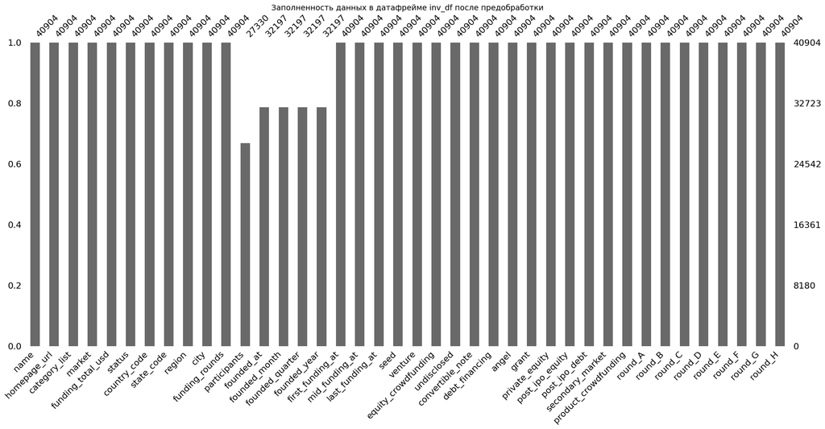

```python
plt.figure(figsize=(12, 6))
msn.bar(inv_df)
plt.title('Заполненность данных в датафрейме inv_df после предобработки', fontsize=14)
plt.show()
```

По итогам предобработки датафрейма `inv_df` у нас всё ещё остались пропуски в столбце `participants`, а также в столбцах с датами (`founded_at`, `founded_month`, `founded_quarter`, `founded_year`). Убедимся что в них стоят заглушки (NA для столбца `participants` и NaT для столбцов с датами), которые нужны для корректной работы используемых библиотек при обработке таких пропусков без ошибок.

```python
# Проверка пропусков в искомых столбцах
target_cols = ['participants', 'founded_at', 'founded_month', 'founded_quarter', 'founded_year']

print("Проверка системных пропусков (NaN/NaT):")
print("-" * 30)

for col in target_cols:
    # выбираем только те строки, где в конкретном столбце пропуск (isnull)
    # и выводим 5 случайных значений (через .sample)
    print(f"Примеры из столбца {col}:")
    print(inv_df[inv_df[col].isnull()][col].sample(5, random_state=1))
    print("-" * 30)
```

```
Проверка системных пропусков (NaN/NaT):
------------------------------
Примеры из столбца participants:
1188     <NA>
47885    <NA>
49146    <NA>
17654    <NA>
46387    <NA>
Name: participants, dtype: Int64
------------------------------
Примеры из столбца founded_at:
40468   NaT
40771   NaT
41597   NaT
38983   NaT
40893   NaT
Name: founded_at, dtype: datetime64[ns]
------------------------------
Примеры из столбца founded_month:
40468   NaT
40771   NaT
41597   NaT
38983   NaT
40893   NaT
Name: founded_month, dtype: datetime64[ns]
------------------------------
Примеры из столбца founded_quarter:
40468   NaT
40771   NaT
41597   NaT
38983   NaT
40893   NaT
Name: founded_quarter, dtype: datetime64[ns]
------------------------------
Примеры из столбца founded_year:
40468   NaT
40771   NaT
41597   NaT
38983   NaT
40893   NaT
Name: founded_year, dtype: datetime64[ns]
------------------------------
```

Заполнять их каким-либо иным образом не нужно, так как это может исказить дальнейший анализ.

Теперь перейдём к датафрейму rtn_df. Так как данный датафрейм изначально был намного более компактным, и что более важно - полным, предобработка в его случае потребуется минимальная.

```python
# Установка столбца year в качестве индекса
rtn_df.set_index('year', inplace=True)

# Приведение финансовых данных rtn_df к такому же виду как в inv_df
finance_cols_rtn = rtn_df.columns.difference(['year'])
rtn_df[finance_cols_rtn] *= 1000000

# Проверка результата
print("Обновлённая информация о датафрейме rtn_df:")
rtn_df.info()
rtn_df.head(10)
```

```
Обновлённая информация о датафрейме rtn_df:
<class 'pandas.core.frame.DataFrame'>
Index: 15 entries, 2000 to 2014
Data columns (total 13 columns):
 #   Column                Non-Null Count  Dtype
---  ------                --------------  -----
 0   seed                  15 non-null     float64
 1   venture               15 non-null     float64
 2   equity_crowdfunding   15 non-null     float64
 3   undisclosed           15 non-null     float64
 4   convertible_note      15 non-null     float64
 5   debt_financing        15 non-null     float64
 6   angel                 15 non-null     float64
 7   grant                 15 non-null     float64
 8   private_equity        15 non-null     float64
 9   post_ipo_equity       15 non-null     float64
 10  post_ipo_debt         15 non-null     float64
 11  secondary_market      15 non-null     float64
 12  product_crowdfunding  15 non-null     float64
dtypes: float64(13)
memory usage: 1.6 KB
```

| year | seed | venture | equity_crowdfunding | undisclosed | convertible_note | debt_financing | angel | grant | private_equity | post_ipo_equity | post_ipo_debt | secondary_market | product_crowdfunding |
| --- | --- | --- | --- | --- | --- | --- | --- | --- | --- | --- | --- | --- | --- |
| 2000 | 16700000.0 | 5.540000e+07 | 0.0 | 78210000.0 | 0.0 | 8660000.0 | 6430000.0 | 0.0 | 0.0 | 940000.0 | 0.0 | 200000.0 | 0.0 |
| 2001 | 2880000.0 | 2.349000e+07 | 0.0 | 21500000.0 | 10000.0 | 4490000.0 | 1180000.0 | 0.0 | 0.0 | 460000.0 | 0.0 | 460000.0 | 0.0 |
| 2002 | 6590000.0 | 2.094200e+08 | 0.0 | 25770000.0 | 20000.0 | 3420000.0 | 3410000.0 | 0.0 | 1510000.0 | 340000.0 | 0.0 | 60000.0 | 0.0 |
| 2003 | 7740000.0 | 2.338600e+08 | 0.0 | 9400000.0 | 10000.0 | 1090000.0 | 3410000.0 | 0.0 | 1620000.0 | 2110000.0 | 0.0 | 80000.0 | 0.0 |
| 2004 | 9930000.0 | 5.559000e+08 | 0.0 | 33190000.0 | 10000.0 | 13550000.0 | 9180000.0 | 0.0 | 2190000.0 | 3380000.0 | 0.0 | 550000.0 | 0.0 |
| 2005 | 26600000.0 | 2.628920e+09 | 0.0 | 9510000.0 | 20000.0 | 35090000.0 | 31060000.0 | 0.0 | 2400000.0 | 3510000.0 | 0.0 | 50000.0 | 0.0 |
| 2006 | 61810000.0 | 3.100180e+09 | 190000.0 | 46740000.0 | 1780000.0 | 113210000.0 | 47750000.0 | 0.0 | 16670000.0 | 20580000.0 | 0.0 | 120000.0 | 0.0 |
| 2007 | 70410000.0 | 3.585370e+09 | 10000.0 | 55370000.0 | 3220000.0 | 125680000.0 | 164510000.0 | 0.0 | 88810000.0 | 24360000.0 | 0.0 | 570000.0 | 0.0 |
| 2008 | 89720000.0 | 2.717020e+09 | 30000.0 | 41020000.0 | 1710000.0 | 397540000.0 | 102830000.0 | 0.0 | 130380000.0 | 84280000.0 | 0.0 | 470000.0 | 0.0 |
| 2009 | 160210000.0 | 2.501290e+09 | 180000.0 | 37500000.0 | 2250000.0 | 394100000.0 | 97210000.0 | 0.0 | 203700000.0 | 76760000.0 | 0.0 | 120000.0 | 20000.0 |

### Выводы по итогам предобработки данных

#### **1. Очистка и объем данных**

- **Удаление мусора:** Из исходного датасета было отсеяно **13 390 строк** (около **24.6%**). Мы полностью избавились от технических пустых строк, дубликатов и записей без данных о финансировании.
- **Финальный актив:** Сформирован массив из **40 904 компаний**. Оптимизация типов позволила снизить потребление памяти с **16.6 МБ до 12.9 МБ**.

#### **2. Восстановление и обработка пропусков**

- **Даты финансирования:** Достигнуто **0% пропусков** в столбцах `first_funding_at`, `mid_funding_at` и `last_funding_at`. Благодаря расчету середины интервала мы получили идеальную базу для анализа сроков инвестиций.
- **Текстовые заглушки:** Пустоты в столбцах `market`, `status`, `country_code` и др. заполнены метками `'unknown'` и `'Other'`. Это позволит проводить группировку по 100% данных без потери строк.
- **Сознательные пропуски:** В столбцах `participants` и `founded_at` сохранены системные `NaN/NaT`. Это защищает итоговую статистику от искажения (например, чтобы выдуманные даты не влияли на расчет среднего возраста компаний).

#### **3. Техническое состояние и типизация**

- **Типы данных:** Все колонки переведены в корректные форматы: даты в `datetime64`, количества в `Int64`, деньги в `float64`.
- **Синхронизация таблиц:** Таблица возвратов `rtn_df` приведена к единому масштабу с инвестициями (доллары). Год установлен в качестве индекса, что упрощает навигацию и защищает временную шкалу.

#### **Итог**

Данные полностью очищены и подготовлены для выполнения задач следующего раздела.

## Шаг 2. Инжиниринг признаков

При выполнении заданий не забывайте интерпретировать полученные результаты и делать промежуточные выводы.

### 2.1. Группы по срокам финансирования

**Задача:**  
Разделите все компании на три группы:

- Единичное финансирование — был всего один раунд финансирования.
- Срок финансирования до года — между первым и последним раундом финансирования прошло не более года.
- Срок финансирования более года.

Визуализируйте соотношение этих групп, создав два графика:

- По количеству компаний: Покажите, какой процент от общего числа компаний относится к каждой из трёх групп.
- По объёму инвестиций: Отобразите, какую долю от общего объёма привлечённых средств получила каждая группа.

Совет: Для ясности и согласованности используйте единую цветовую палитру для всех графиков, чтобы каждая категория (например, «Единичное финансирование») всегда отображалась одним цветом.

**Код:**

```
funding_group
Единичное финансирование          24112
Срок финансирования более года    12291
Срок финансирования до года        4501
Name: count, dtype: int64
```

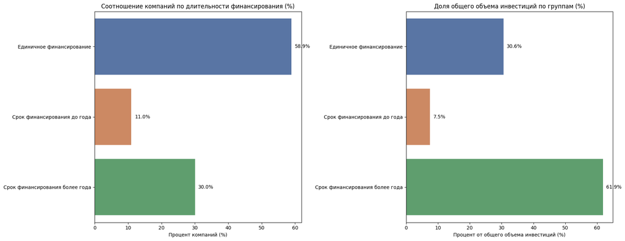

```python
# =======================================================
# ==== Разделение на группы по срокам финансирования ====
# =======================================================

# Рассчитываем продолжительность финансирования в днях
inv_df['funding_duration_days'] = (inv_df['last_funding_at'] - inv_df['first_funding_at']).dt.days

# Определяем функцию категоризации
def categorize_funding_duration(row):
    if row['funding_rounds'] == 1:
        return 'Единичное финансирование'
    elif row['funding_duration_days'] <= 365:
        return 'Срок финансирования до года'
    else:
        return 'Срок финансирования более года'

# Создаем новый столбец 'funding_group' и применяем категоризацию
inv_df['funding_group'] = inv_df.apply(categorize_funding_duration, axis=1)

# Проверка результатов
print(inv_df['funding_group'].value_counts())

# ========================================
# ==== Визуализация соотношения групп ====
# ========================================

# Создание единой цветовой палитры для согласованности графиков
# Определение порядка групп для графиков
group_order = ['Единичное финансирование', 'Срок финансирования до года', 'Срок финансирования более года']
# Цвета: синий, оранжевый, зеленый
custom_palette = {'Единичное финансирование': '#4c72b0',
                  'Срок финансирования до года': '#dd8452',
                  'Срок финансирования более года': '#55a868'}

fig, axes = plt.subplots(1, 2, figsize=(18, 7))

# График 1: По количеству компаний (процент от общего числа)
# Используем value_counts(normalize=True) * 100 для расчета процентов
group_counts_df = inv_df['funding_group'].value_counts(normalize=True).loc[group_order].mul(100).rename('percent').reset_index()
sns.barplot(
    ax=axes[0],
    x='percent',
    y='funding_group',
    data=group_counts_df,
    hue='funding_group',
    palette=custom_palette,
    order=group_order,
    legend=False
)
axes[0].set_title('Соотношение компаний по длительности финансирования (%)')
axes[0].set_xlabel('Процент компаний (%)')
axes[0].set_ylabel('')

# Добавление подписей значений на график 1
for index, value in enumerate(group_counts_df['percent']):
    axes[0].text(value + 1, index, f'{value:.1f}%', va='center')

# График 2: По объёму инвестиций (доля от общего объёма)
total_invest_sum_df = inv_df.groupby('funding_group')['funding_total_usd'].sum()
total_invest_sum_percent = (total_invest_sum_df / total_invest_sum_df.sum() * 100).loc[group_order].rename('percent').reset_index()

sns.barplot(
    ax=axes[1],
    x='percent',
    y='funding_group',
    data=total_invest_sum_percent,
    hue='funding_group',
    palette=custom_palette,
    order=group_order,
    legend=False
)
axes[1].set_title('Доля общего объема инвестиций по группам (%)')
axes[1].set_xlabel('Процент от общего объема инвестиций (%)')
axes[1].set_ylabel('')

# Добавление подписей значений на график 2
for index, value in enumerate(total_invest_sum_percent['percent']):
    axes[1].text(value + 1, index, f'{value:.1f}%', va='center')

# Оптимизация расположения графиков
plt.tight_layout()
plt.show()
```

**Выводы по задаче 2.1:**

Анализ показывает значительное расхождение между количеством компаний и объемом привлеченных инвестиций в зависимости от длительности финансирования:

- Количество компаний: Подавляющее большинство стартапов (примерно 59%) получают единичное финансирование и не проходят через последующие раунды. Это говорит о высоком уровне отсева на ранних стадиях или о том, что многие компании не масштабируются до уровня венчурных инвестиций.
- Объем инвестиций: Несмотря на то, что компаний с единичным финансированием больше половины, они аккумулируют лишь порядка 30,6% от общего объема средств.
- Крупные вложения: Основная доля капитала (примерно 62%) приходится на компании, которые привлекают инвестиции более года. Эти компании (их примерно 30%) — получают больше всего денег, так как они проходят через множество крупных раундов (A, B, C и т.д.).
- Быстрые раунды: Компании, завершающие цикл финансирования до года (примерно 11% компаний), занимают наименьшую долю как по количеству компаний, так и по объему инвестиций (примерно 7,5%).

**Ключевой вывод для инвесторов:**  
Для того чтобы найти перспективную компанию для покупки и развития, следует фокусироваться не на массовом сегменте единичного финансирования, а на сегменте "Срок финансирования более года", так как именно там концентрируется основной капитал и, вероятно, самые масштабируемые проекты.

### 2.2 Выделение средних и нишевых сегментов рынка

**Задача:**  
Компании указывают свой сегмент рынка в столбце `market`. Рассчитайте, как часто в датасете встречается каждый из сегментов. Сегменты, к которым относится более 120 компаний, отнесите к массовым, сегменты, в которые входит от 35 до 120 включительно, отнесите к средним, а сегменты до 35 компаний отнесите к нишевым. Рассчитайте, сколько сегментов попадает в каждую из категорий.

Постройте график распределения количества компаний в сегментах и отобразите на нём разделение на нишевые и средние сегменты.

Оставьте в столбце `market` только массовые сегменты. Для остальных сегментов замените значения на заглушки — `niche` для нишевых и `mid` для средних. Дальнейшие исследования выполняйте с учётом этой замены. Индивидуальные сегменты внутри средней и нишевой групп рассматривать не нужно — они объединяются в два общих сегмента.

**Код:**

```
Количество сегментов по типам:
type
Нишевый     289
Средний      57
Массовый     49
Name: count, dtype: int64
```

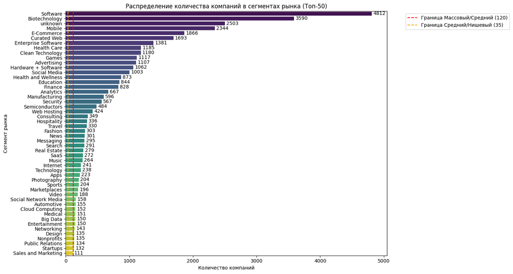

```
Проверка новых значений в столбце 'market':
market
Software                4812
mid                     3839
Biotechnology           3590
unknown                 2503
Mobile                  2344
E-Commerce              1866
Curated Web             1693
Enterprise Software     1381
Health Care             1185
Clean Technology        1180
Games                   1117
Advertising             1107
Hardware + Software     1062
Social Media            1003
Health and Wellness      873
Education                844
niche                    830
Finance                  828
Analytics                667
Manufacturing            596
Security                 567
Semiconductors           484
Web Hosting              424
Consulting               349
Hospitality              336
Travel                   330
Fashion                  303
News                     301
Messaging                295
Search                   291
Real Estate              279
SaaS                     272
Music                    264
Internet                 241
Technology               238
Apps                     223
Sports                   204
Photography              204
Marketplaces             196
Video                    188
Social Network Media     158
Automotive               155
Cloud Computing          152
Medical                  151
Entertainment            150
Big Data                 150
Networking               143
Nonprofits               135
Design                   135
Public Relations         134
Startups                 132
Name: count, dtype: int64
```

```python
# ================================================================
# ==== Расчёт частоты встречаемости сегментов и категоризация ====
# ================================================================

# Считаем количество компаний в каждом сегменте market
market_counts = inv_df['market'].value_counts()

# Определяем пороговые значения
MASSIVE_THRESHOLD = 120
MID_THRESHOLD = 35

# Создание датафрейма для анализа сегментов
segments_df = pd.DataFrame({
    'count': market_counts.values,
    'market': market_counts.index
})

# Функция для определения типа сегмента
def segment_type(count):
    if count > MASSIVE_THRESHOLD:
        return 'Массовый'
    elif count >= MID_THRESHOLD:
        return 'Средний'
    else:
        return 'Нишевый'

segments_df['type'] = segments_df['count'].apply(segment_type)

# Расчет количества сегментов в каждой категории
segment_type_counts = segments_df['type'].value_counts()
print("Количество сегментов по типам:")
print(segment_type_counts)

# ====================================================================
# ==== Визуализация распределения количества компаний в сегментах ====
# ====================================================================

plt.figure(figsize=(15, 8))
# Сортировка в целях создания более понятного графика
segments_df_sorted = segments_df.sort_values(by='count', ascending=False)

# Использование order для управления порядком на графике
ax = sns.barplot(
    x='count',
    y='market',
    data=segments_df_sorted.head(50),
    hue='market',
    palette='viridis',
    legend=False
)

for i in ax.containers:
    ax.bar_label(i, padding=3, fontsize=10)

# Добавление горизонтальных линий для обозначения границ категорий
plt.axvline(x=MASSIVE_THRESHOLD, color='r', linestyle='--', label=f'Граница Массовый/Средний ({MASSIVE_THRESHOLD})')
plt.axvline(x=MID_THRESHOLD, color='orange', linestyle='--', label=f'Граница Средний/Нишевый ({MID_THRESHOLD})')

plt.title('Распределение количества компаний в сегментах рынка (Топ-50)')
plt.xlabel('Количество компаний')
plt.ylabel('Сегмент рынка')
plt.legend(bbox_to_anchor=(1.05, 1), loc='upper left')
plt.tight_layout()
plt.show()

# =================================================
# ==== Трансформация столбца 'market' в inv_df ====
# =================================================

# Создаем словарь отображения: {старое_имя_сегмента: новое_имя_сегмента}
# Сначала определяем, какие сегменты массовые
massive_markets = market_counts[market_counts > MASSIVE_THRESHOLD].index

# Применяем замену в исходном DataFrame inv_df
def replace_market_name(market_name):
    if market_name in massive_markets:
        return market_name
    elif market_name in market_counts[ (market_counts >= MID_THRESHOLD) & (market_counts <= MASSIVE_THRESHOLD) ].index:
        return 'mid'
    else:
        return 'niche'

inv_df['market'] = inv_df['market'].apply(replace_market_name)

# Проверка результата трансформации
print("\nПроверка новых значений в столбце 'market':")
print(inv_df['market'].value_counts())
```

**Выводы по задаче 2.2:**

**Ключевой вывод для инвесторов:** Чтобы эффективно вкладывать деньги, финансовой компании не стоит распыляться на сотни мелких, нишевых рынков. Основное внимание нужно сосредоточить на нескольких крупных, массовых сегментах (таких как Software, Biotechnology, Mobile), которые мы выделили.

## Шаг 3. Работа с выбросами и анализ

### 3.1. Анализируем и помечаем выбросы в каждом из сегментов

**Задача:**  
Заказчика интересует обычный для рассматриваемого периода размер средств, который предоставлялся компаниям.

По предобработанному столбцу `funding_total_usd` графическим образом оцените, какой размер общего финансирования для одной компании будет типичным, а какой — выбивающимся. Укажите интервал, в котором лежат типичные значения.

Определите компании с аномальным объёмом общего финансирования — используйте метод IQR отдельно по каждому сегменту. Напомним, что все нишевые сегменты должны быть объединены в одну группу, а средние — в другую.

Определите сегменты рынка с наибольшей долей компаний, получивших аномальное финансирование, и выведите топ таких сегментов.

**Код:**

Для начала посмотрим на общее распределение `funding_total_usd`, чтобы увидеть «типичные» значения и масштаб выбросов.

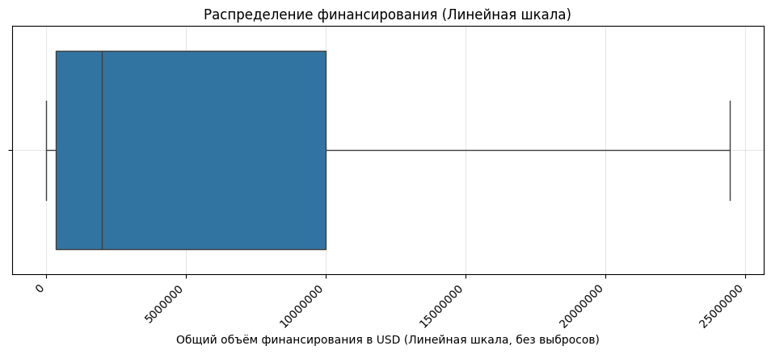

```
Расчетная верхняя граница 'уса' (без учета ограничения по данным): 24,475,000 USD
```

```python
plt.figure(figsize=(12, 4))
ax = sns.boxplot(x=inv_df['funding_total_usd'], showfliers=False)

plt.xlabel('Общий объём финансирования в USD (Линейная шкала, без выбросов)')
plt.title('Распределение финансирования (Линейная шкала)')
plt.grid(True, alpha=0.3)

# Настройка формата меток оси X для читаемости больших чисел
formatter = ticker.ScalarFormatter()
formatter.set_scientific(False)
formatter.useOffset = False # Важно для больших чисел на линейной шкале
ax.xaxis.set_major_formatter(formatter)
plt.xticks(rotation=45, ha='right')

plt.show()

q1 = inv_df['funding_total_usd'].quantile(0.25)
q3 = inv_df['funding_total_usd'].quantile(0.75)
iqr = q3 - q1
upper_whisker = q3 + 1.5 * iqr

print(f"Расчетная верхняя граница 'уса' (без учета ограничения по данным): {upper_whisker:,.0f} USD")
```

Теперь напишем функцию, которая рассчитает границы выбросов отдельно для каждой группы в market и пометит их.

```python
# Функция для вычисления маски выбросов
def get_outliers_mask(series):
    Q1 = series.quantile(0.25)
    Q3 = series.quantile(0.75)
    IQR = Q3 - Q1
    lower_bound = Q1 - 1.5 * IQR
    upper_bound = Q3 + 1.5 * IQR
    return (series < lower_bound) | (series > upper_bound)

# Применяем группировку и трансформируем колонку
inv_df['is_outlier'] = inv_df.groupby('market')['funding_total_usd'].transform(get_outliers_mask)

print(f"Всего аномальных компаний: {inv_df['is_outlier'].sum()}")
```

```
Всего аномальных компаний: 5244
```

Рассчитаем, в каких сегментах процент выбросов выше всего.

```python
# Группируем по рынку и считаем долю True в столбце is_outlier
outlier_shares = inv_df.groupby('market')['is_outlier'].mean().sort_values(ascending=False)

print("\nТоп-10 сегментов с наибольшей долей аномального финансирования:")
print((outlier_shares * 100).head(10).apply(lambda x: f"{x:.2f}%"))
```

```
Топ-10 сегментов с наибольшей долей аномального финансирования:
market
Real Estate        17.20%
Entertainment      16.67%
Consulting         16.62%
Search             16.49%
Cloud Computing    16.45%
Photography        16.18%
SaaS               16.18%
Technology         15.97%
Video              15.96%
niche              15.90%
Name: is_outlier, dtype: object
```

**Выводы по задаче 3.1:**  
Инвестиции распределены очень неравномерно: большинство компаний получают небольшие суммы, а небольшое количество компаний — огромные деньги.

**Ключевой вывод для инвесторов:**  
Большая часть компаний получает относительно скромное финансирование (до 10 000 000 USD), но существует значительное количество компаний-гигантов, которые привлекают суммы, на порядки превышающие средние показатели. Рынки Недвижимости и Развлечений выделяются как наиболее волатильные с точки зрения инвестиций. Хотя эти рынки могут быть небольшими, если компания на них "выстреливает", она привлекает экстремально большие суммы. Группа niche также демонстрирует эту особенность — редкие проекты в узких нишах получают финансирование уровня мировых гигантов.

### 3.2 Определяем границы рассматриваемого периода, отбрасываем аномалии

**Задача:**  
Проверьте по датасету, можно ли считать, что вам предоставили полные данные за 2014 год. Затем исключите из датасета компании, которые вы ранее посчитали получившими аномальное финансирование.

Когда исключите аномальные записи, на основе столбцов `mid_funding_at` и `funding_rounds` оставьте в датасете данные только об определённых компаниях. Они должны были получать финансирование в годы, когда было зафиксировано 50 или более раундов финансирования.

**Код:**

```
Количество раундов финансирования по годам:
first_funding_year
2010     9035
2011     9427
2012     9961
2013    10180
2014     7236
Name: funding_rounds, dtype: Int64
```

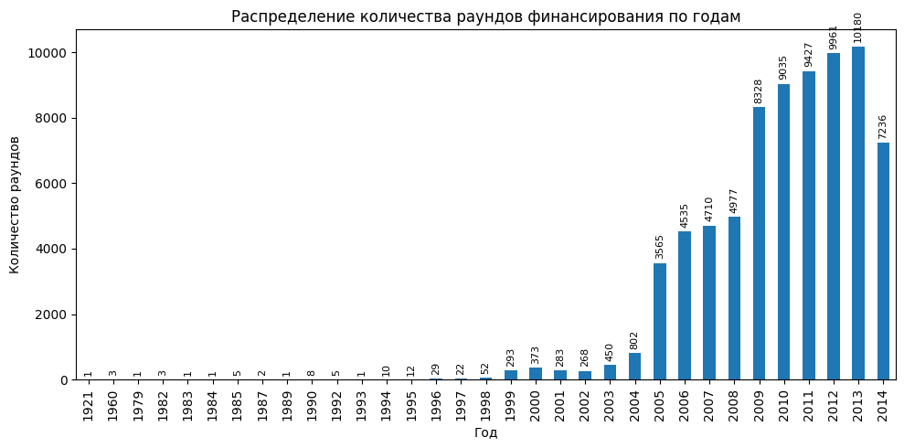

```
Компаний до удаления аномалий: 40904
Компаний после удаления аномалий: 35660
Удалено компаний (аномалии): 5244

Годы с >= 50 раундами финансирования: [1999, 2000, 2001, 2002, 2003, 2004, 2005, 2006, 2007, 2008, 2009, 2010, 2011, 2012, 2013, 2014]
Компаний после финальной фильтрации по активности: 35608
```

```python
# ======================================================
# ==== ЧАСТЬ 1: Проверка полноты данных за 2014 год ====
# ======================================================
# Создание нового столбца путём извлечения года из first_funding_at
inv_df['first_funding_year'] = inv_df['first_funding_at'].dt.year

# Считаем количество раундов финансирования по годам
rounds_per_year = inv_df.groupby('first_funding_year')['funding_rounds'].sum()

print("Количество раундов финансирования по годам:")
print(rounds_per_year.tail())

# Визуализация для оценки тренда
plt.figure(figsize=(10, 5))
ax = rounds_per_year.plot(kind='bar')
plt.title('Распределение количества раундов финансирования по годам')
plt.xlabel('Год')
plt.ylabel('Количество раундов')

for i in ax.containers:
    # Добавляем подписи, немного увеличиваем шрифт и поворачиваем их для читаемости
    ax.bar_label(i, padding=3, fontsize=8, rotation=90)

plt.tight_layout()
plt.show()

# =======================================
# ==== ЧАСТЬ 2: Фильтрация аномалий ====
# =======================================

# Использование маски 'is_outlier' которая была создана ранее
initial_count = len(inv_df)
inv_df = inv_df[~inv_df['is_outlier']]
filtered_count = len(inv_df)

print(f"\nКомпаний до удаления аномалий: {initial_count}")
print(f"Компаний после удаления аномалий: {filtered_count}")
print(f"Удалено компаний (аномалии): {initial_count - filtered_count}")

# =====================================================================
# ==== ЧАСТЬ 3: Фильтрация по активности рынка (50+ раундов в год) ====
# =====================================================================

# Подсчёт общего количества раундов по каждому году в очищенном датасете
total_rounds_per_year_cleaned = inv_df.groupby('first_funding_year')['funding_rounds'].sum()

# Определение годов, в которых было 50 или более раундов
active_years = total_rounds_per_year_cleaned[total_rounds_per_year_cleaned >= 50].index.tolist()

print(f"\nГоды с >= 50 раундами финансирования: {active_years}")

# Фильтрация датасета (оставляем только те компании, чье первое финансирование пришлось на активные годы)
inv_df = inv_df[inv_df['first_funding_year'].isin(active_years)]

print(f"Компаний после финальной фильтрации по активности: {len(inv_df)}")

# Удаление временных колонок
inv_df = inv_df.drop(columns=['is_outlier', 'first_funding_year'], errors='ignore')
```

**Выводы по задаче 3.2:**

- Данные за 2014 год не являются полными. Это видно из резкого падения количества раундов финансирования до 7236 в 2014 году, тогда как в предыдущие годы наблюдался пик и рост (например, 10180 раундов в 2013 году).
- Компании с аномальным финансированием исключены. Мы удалили 5244 компании (около 12.8% от исходного датасета), которые получили суммы, выходящие за рамки "типичных" для их сегментов.
- Датасет ограничен периодом активного рынка. После всех фильтраций в датасете остались компании, получившие финансирование в годы, когда на рынке было зафиксировано 50 или более раундов. Это период с 1999 по 2014 год, который включает 35 608 компаний.